# Datorlaboration 2

Author

Minhui Zhong

## Ladda paket

```r
library(tidyverse)
library(remotes)
library(sda123)
library(SUdatasets)
library(dplyr)
```

## Del 1 - F-test för jämförelse mellan modeller

```r
df <- tibble(bike)


datb <- df %>% select(!(dteday))
head(datb)
```

```
# A tibble: 6 × 11
  season    yr  mnth holiday weekday workingday weathersit  temp   hum windspeed
   <int> <int> <int>   <int>   <int>      <int>      <int> <dbl> <dbl>     <dbl>
1      1     0     1       0       6          0          2 0.344 0.806    0.160
2      1     0     1       0       0          0          2 0.363 0.696    0.249
3      1     0     1       0       1          1          1 0.196 0.437    0.248
4      1     0     1       0       2          1          1 0.2   0.590    0.160
5      1     0     1       0       3          1          1 0.227 0.437    0.187
6      1     0     1       0       4          1          1 0.204 0.518    0.0896
# ℹ 1 more variable: nRides <int>
```

```r
#datb <- tibble(df$season, df$yr, df$mnth, df$holiday, df$weekday, df$workingday, df$weathersit, df$temp, df$hum, df$windspeed, df$nRides)
#datb
```

```r
#??bike -kolla genom datatyp betydelser
datb$season <- as.factor(datb$season)
#datb <- datb %>% mutate(season= as.factor(season))
#str(data$season)
#datb <- datb %>% mutate(season= as.numeric(season))
#str(data$season)
#datb <- datb %>% mutate(season1 = ifelse(season == 1,1,0),season2 = ifelse(season == 2,1,0),season3 = ifelse(season == 3,1,0),season4 = ifelse(season == 4,1,0),) #- skapa dummy variabler i en ny columen i dataset
#datb <- datb %>% mutate(new_columns = paste0("season_", season),vals=1) %>%   pivot_wider(names_from = new_columns, values_from = vals, values_fill = 0)
?bike
```

```
Help on topic 'bike' was found in the following packages:

  Package               Library
  sda123                /Library/Frameworks/R.framework/Versions/4.3-arm64/Resources/library
  SUdatasets            /Library/Frameworks/R.framework/Versions/4.3-arm64/Resources/library


Using the first match ...
```

```r
UnRestricted_model <- lm(nRides ~ temp + hum + season, data = datb)
reg_summary(UnRestricted_model) #Full modell FM
```

```
Analysis of variance - ANOVA
------------------------------------------------
       df         SS        MS      F      Pr(>F)
Regr    5 1396592039 279318408 150.79 1.1051e-109
Error 725 1342943353   1852336
Total 730 2739535392

Measures of model fit
------------------------------------------------
  Root MSE         R2     R2-adj
1361.00539    0.50979    0.50641

Parameter estimates
------------------------------------------------
            Estimate Std. Error t value   Pr(>|t|)
(Intercept)  2500.83     265.04  9.4355 5.1639e-20
temp         6718.10     494.97 13.5727 1.4835e-37
hum         -3254.39     364.06 -8.9391 3.2177e-18
season2       874.47     187.19  4.6715 3.5648e-06
season3       460.02     246.01  1.8699 6.1894e-02
season4      1562.48     158.23  9.8747 1.1595e-21
```

```r
Restricted_model <- lm(nRides ~ temp + hum, data = datb)
reg_summary(Restricted_model) #Reducerad modell RM
```

```
Analysis of variance - ANOVA
------------------------------------------------
       df         SS        MS      F     Pr(>F)
Regr    2 1169231889 584615944 271.03 1.0559e-88
Error 728 1570303503   2157010
Total 730 2739535392

Measures of model fit
------------------------------------------------
  Root MSE         R2     R2-adj
1468.67638    0.42680    0.42522

Parameter estimates
------------------------------------------------
            Estimate Std. Error t value   Pr(>|t|)
(Intercept)   2657.9     272.42  9.7565 3.2258e-21
temp          6887.0     299.38 23.0042 1.9558e-88
hum          -2492.9     384.76 -6.4789 1.7012e-10
```

### F-test

H0:beta 3 = beta 4=beta5=0

H1:Inga restriktioner på regressionskoefficienterna

För att utför ett F-test i de två modellen kräver vi ta reda på (( RFM^2-RRM^2)/(p-q))/((1-RFM^2)/(n-p-1)

Vi vet att RFM^2 = 0.50979 , RRM^2 =0.42680 , n=731, p=5, q=2

alltså jag fick att Fobs > Fcrit då förkastar jag H0

```r
n <- nrow(datb)
qf(1 - 0.1, df1 = 3, df2 = 731 - 5 - 1)
```

```
[1] 2.091359
```

## Del2 - Multikollinearitet och variance inflation factor (VIF)

```r
#install.packages("corrr")
library(corrr)
new_df <- df %>% select(temp,hum,windspeed)
corr_matrix <- correlate(new_df)
```

```
Correlation computed with
• Method: 'pearson'
• Missing treated using: 'pairwise.complete.obs'
```

```r
corr_matrix
```

```
# A tibble: 3 × 4
  term        temp    hum windspeed
  <chr>      <dbl>  <dbl>     <dbl>
1 temp      NA      0.127    -0.158
2 hum        0.127 NA        -0.248
3 windspeed -0.158 -0.248    NA
```

```r
shave(corr_matrix) #skriva ut halva matrisen
```

```
# A tibble: 3 × 4
  term        temp    hum windspeed
  <chr>      <dbl>  <dbl>     <dbl>
1 temp      NA     NA            NA
2 hum        0.127 NA            NA
3 windspeed -0.158 -0.248        NA
```

```r
corr_matrix <- correlate(new_df, diagonal = 1)
```

```
Correlation computed with
• Method: 'pearson'
• Missing treated using: 'pairwise.complete.obs'
```

```r
corr_matrix
```

```
# A tibble: 3 × 4
  term        temp    hum windspeed
  <chr>      <dbl>  <dbl>     <dbl>
1 temp       1      0.127    -0.158
2 hum        0.127  1        -0.248
3 windspeed -0.158 -0.248     1
```

```r
# new_model: nRides = 𝛽0 + 𝛽1temp + 𝛽2windspeed + 𝛽3vår + 𝛽4sommar + 𝛽5höst + 𝜀
??bike
new_season <- datb %>% mutate(winter = ifelse(season == 1,1,0),spring = ifelse(season == 2,1,0),summer = ifelse(season == 3,1,0),fall = ifelse(season == 4,1,0))#- skapa dummy variabler i en ny columen i dataset
new_model <- lm(nRides ~ temp + windspeed + spring + summer + fall, data = new_season)
reg_summary(new_model) #Full modell FM
```

```
Analysis of variance - ANOVA
------------------------------------------------
       df         SS        MS      F     Pr(>F)
Regr    5 1280334070 256066814 127.23 1.1428e-96
Error 725 1459201322   2012691
Total 730 2739535392

Measures of model fit
------------------------------------------------
  Root MSE         R2     R2-adj
1418.69358    0.46735    0.46368

Parameter estimates
------------------------------------------------
            Estimate Std. Error t value   Pr(>|t|)
(Intercept)  1386.20     245.84  5.6386 2.4574e-08
temp         6095.13     514.27 11.8521 9.5882e-30
windspeed   -2782.15     700.40 -3.9722 7.8309e-05
spring        854.10     195.11  4.3775 1.3769e-05
summer        431.85     256.83  1.6815 9.3100e-02
fall         1242.81     164.87  7.5380 1.4278e-13
```

```r
new_model1 <- lm(hum ~ temp + windspeed + spring + summer + fall, data = new_season)
reg_summary(new_model1)
```

```
Analysis of variance - ANOVA
------------------------------------------------
       df      SS       MS      F     Pr(>F)
Regr    5  1.4506 0.290125 15.746 9.7813e-15
Error 725 13.3582 0.018425
Total 730 14.8088

Measures of model fit
------------------------------------------------
Root MSE       R2   R2-adj
0.135739 0.097957 0.091736

Parameter estimates
------------------------------------------------
              Estimate Std. Error  t value    Pr(>|t|)
(Intercept)  0.6285758   0.023522 26.72300 4.8493e-110
temp         0.1261085   0.049204  2.56295  1.0579e-02
windspeed   -0.3879112   0.067013 -5.78856  1.0569e-08
spring       0.0086612   0.018668  0.46396  6.4282e-01
summer      -0.0174077   0.024573 -0.70840  4.7892e-01
fall         0.0535300   0.015775  3.39337  7.2792e-04
```

```r
1/(1-0.54)
```

```
[1] 2.173913
```

```r
#Tumregel: VIF > 10 är stark multikollinearitet.
```

## Del 3 - Test av homoskedasticitet med White’s test

```r
temp2 <- datb$temp^2
windspeed2 <- datb$windspeed^2
new_df <- datb %>% mutate(temp2,windspeed2)
reg_modell <- lm(nRides ~ temp + windspeed, data = new_df)
new_df <- new_df %>% mutate(e2 = reg_modell$residuals^2)
new_df
```

```
# A tibble: 731 × 14
   season    yr  mnth holiday weekday workingday weathersit  temp   hum
   <fct>  <int> <int>   <int>   <int>      <int>      <int> <dbl> <dbl>
 1 1          0     1       0       6          0          2 0.344 0.806
 2 1          0     1       0       0          0          2 0.363 0.696
 3 1          0     1       0       1          1          1 0.196 0.437
 4 1          0     1       0       2          1          1 0.2   0.590
 5 1          0     1       0       3          1          1 0.227 0.437
 6 1          0     1       0       4          1          1 0.204 0.518
 7 1          0     1       0       5          1          2 0.197 0.499
 8 1          0     1       0       6          0          2 0.165 0.536
 9 1          0     1       0       0          0          1 0.138 0.434
10 1          0     1       0       1          1          1 0.151 0.483
# ℹ 721 more rows
# ℹ 5 more variables: windspeed <dbl>, nRides <int>, temp2 <dbl>,
#   windspeed2 <dbl>, e2 <dbl>
```

```r
reg_white <- lm(e2 ~ temp + temp2 + windspeed + windspeed2 + temp:windspeed, data = new_df)
reg_summary(reg_white)
```

```
Analysis of variance - ANOVA
------------------------------------------------
       df         SS         MS     F     Pr(>F)
Regr    5 1.5038e+14 3.0075e+13 4.462 0.00051929
Error 725 4.8868e+15 6.7404e+12
Total 730 5.0371e+15

Measures of model fit
------------------------------------------------
  Root MSE         R2     R2-adj
2.5962e+06 2.9854e-02 2.3163e-02

Parameter estimates
------------------------------------------------
               Estimate Std. Error   t value  Pr(>|t|)
(Intercept)     -338830    1257430 -0.269463 0.7876503
temp            9042977    3682749  2.455497 0.0143027
temp2          -8854930    3138571 -2.821325 0.0049134
windspeed        389845    6925148  0.056294 0.9551230
windspeed2     -5763240   11837132 -0.486878 0.6264919
temp:windspeed  7591486    7976906  0.951683 0.3415749
```

White’s test

H0: feltermerna har samma varians(homoskedastiska)

H1: feltermerna har olika varians (heteroskedastiska)

Testvariabeln för Whites test är nR^2 och för att räkna ut detta behöver jag hämta värdet av R^2 dvs e^2 och sedan multiplicera med antal observationer n. Vi fick alltså nR^2 = 731 x 0.0299=21.82

```r
qchisq(1-0.05,5) # k är antalet restriktioner
```

```
[1] 11.0705
```

```r
qchisq(1-0.01,5) #H0 förkastas på 1% signifikansnivå
```

```
[1] 15.08627
```

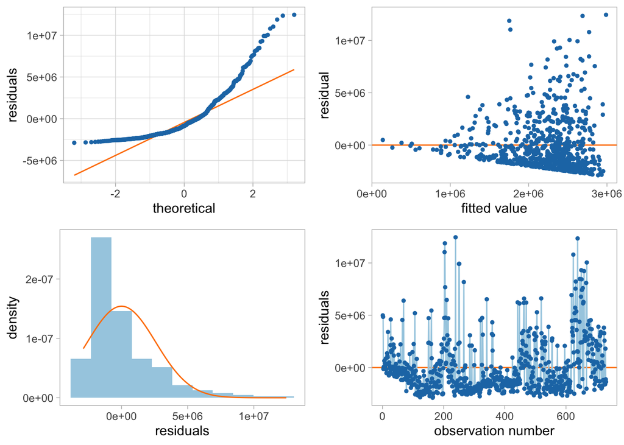

```r
reg_residuals(reg_white)
```